# Outcome-oriented educational tasks with flipbooks

For *Chance Magazine’s* ‘Taking a chance in the classroom’

Evangeline Reynolds, June 2020

A goal of data science and statistics courses is giving students practice preparing and analyzing data. A new style of assignment presents outcome-oriented exercises in ‘flipbooks’ (evamaerey.github.io/flipbooks/about). Typically ‘flipbooks’ present code step-by-step and side-by-side with output. This gives you a movie-like experience, linking new code to the change that it triggers in output. But ‘flipbooks’ can also present *only output*. This mode can be used in data science and statistics classrooms to create engaging outcome-oriented assignments!

# What’s this new style of exercise?

A flipbook data manipulation assignment might look as follows. First, you have a reference section of functions that can be used to accomplish the required tasks. Then a target data frame is introduced. The target will be a final output of a data manipulation pipeline, where the input is a familiar data set (I use the ‘gapminder’ data set, which my students have worked with for data visualization). Then, a walk-through from input to target — including intermediary states — is displayed. Students are instructed to ‘wrangle to it’; i.e., use the new data manipulation functions to get to the target output. A series of additional exercises are structured in the same way. A target is presented. Then a walk-through of states is shown. A collection of slides that constitutes one wrangling exercise follows, and a full set of exercises can be viewed here (https://tinyurl.com/y6b9z5vx).

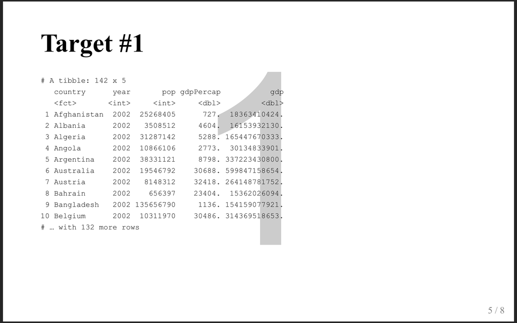

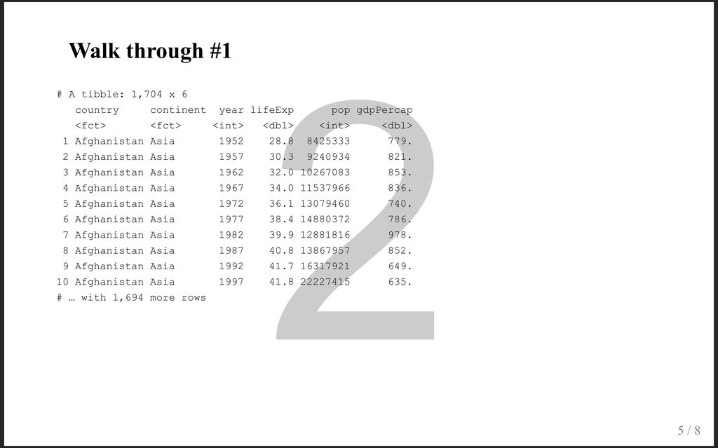

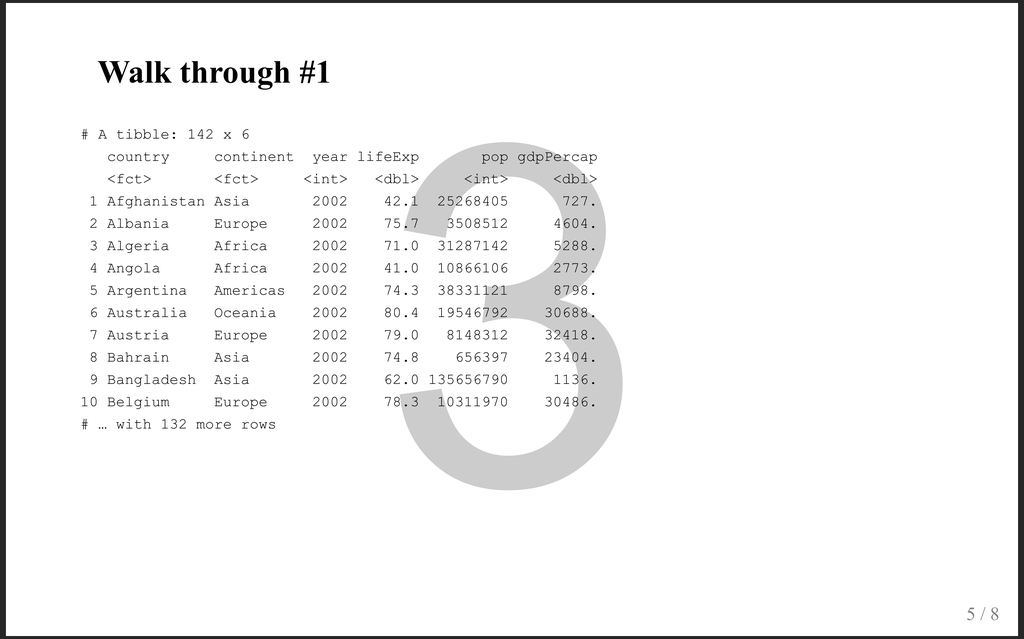

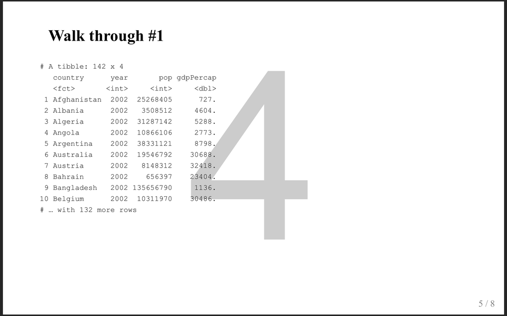

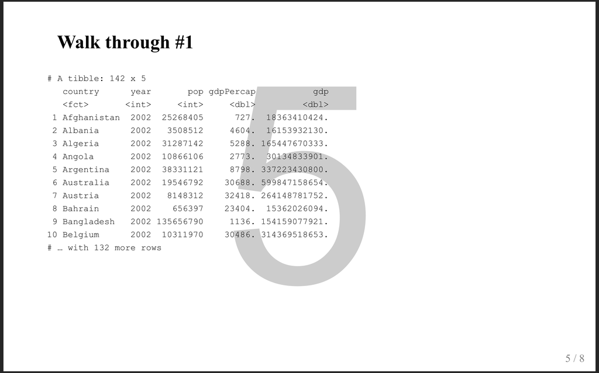

Slides constituting one data wrangling task.